# PV - Datenanalyse

09 Januar 2018

# Präliminarien

Die Programmstücke dienen der Auswertung der Daten, die von der PV-Anlage erzeugt und mit Hilfe des SMA-Portals gelesen werden.

Die Daten liegen tageweise in Dateien vor. Beim Download werden diese von Hand benannt, sie enthalten Datensätze (Zeilen), die im 5-Minuten-Rhythmus erfasst wurden. Beim Einlesen werden sie zusammengefügt.

Die Datensätze enthalten die Größen

zeit — leistung.pv — leistung.stp — netzeinspeisung — netzbezug — batt_ladung — batt_entladung — ladezustand(%)

Einheiten:

- Zeit als Datum-Stunde-Min-Sek
- Alle anderen Größen in W außer
- Ladezustand in % der Batteriekapazität. Laut Herstellerangabe beträgt diese 9,8 kWh, von denen 9,3 KWh verfügbar sind.

```
Im folgenden wird mit einer Batteriekapazität von 0.98 x 10 kWh gerechnet.
```

Es wird sich herausstellen, dass dieser Wert für die Abschätzung von Teilwirkungsgraden eine wesentliche Bedeutung hat.

# Technische Vorbereitungen

Dient nur der Darstellung des Codes, kann überlesen werden, wenn es nur um Anlagendaten geht.

### Laden der nötigen Bibliotheken und Definition von Funktionen.

### Einlesen der Dateien “Daten_dd_mm_yyyy.csv”:

Für jeden Tag liegt eine Datei vor, mit Messwerten im 5-min-Abstand. Alle in der Einheit W, mit Ausnahme von ‘ladezustand’. Dieser wird beim Lesen als Prozentsatz übergeben und anschließend auf $10000 = 100 \%$ normiert. Weil die Batterie eine Kapazität von annähernd $10\, kWh$ besitzt, kann die Zahl 10000 grob mit der Einheit $Wh$ gelesen werden.

Beim Einlesen werden die Kopfzeilen und die erste, sonst leere Datenzeile für 0:00 Uhr ignoriert. Für jeden Tag gibt es also 288 Zeilen, endend mit 0:00 der Folgetages (diese Zeile wird aufgenommen).

Die Zeilen müssen sortiert werden, weil die Dateien nicht in der korrekten zeitlichen Reihenfolge eingelesen werden.

```
Kontrolle der Kopfzeilen auf Gleichheit.
Die Kopfzeilen aller Dateien stimmen ueberein.

Kontrolle auf redundante Zeilen:
Ok, es gibt keine doppelte Zeiten.
```

### Ergänzende Spaltenoperationen und Datenkontrollen

1. Die neue Spalte ‘ct’ zählt die Datenzeilen
2. *Ausgeschaltet*: Über ‘ladezustand’ läuft eine Glättungsfunktion, um einzelne Ausfaelle in den Messungen zu beseitigen.
3. ‘month’, ‘day’ und ‘hour’ werden aus der Variablen ‘zeit’ extrahiert und im Datumsformat “yyyy-mm-dd” bzw. als Zahl 0 - 23 gespeichert.
4. ‘ladediff’ wird als Differenz zwischen dem aktuellen Zustand und dem vorangegangenen Ladezustand berechnet.
5. von W in Wh werden umgerechnet:
   1. batt_ladung, batt_entladung,
   2. leistung.pv, leistung.stp, (bei der bestehende Anlage identisch)
   3. netzeinspeisung, netzbezug

Weil die Leistung jeweils zur Zeit t in 5min-Intervallen erhoben wird, wird in jedem Intervall die Arbeit W = P 5min = P (1/12) h verrichtet. Anm.: In der späteren Auswertung wird dies so interpretiert: Diese el. Arbeit von $P\cdot 5 \mbox{min}$ wird im Zeitintervall $t \pm 2,5 \mbox{min}$ erbracht

```
Oct 2017 hat Daten von  31 Tagen
Nov 2017 hat Daten von  30 Tagen
Dec 2017 hat Daten von  31 Tagen
Jan 2018 hat Daten von  9 Tagen

Warnung: An folgenden Tage liegen weniger als 288 Beobachtungen vor:
2017-10-01 hat nur  280  Beobachtungen.
2018-01-09 hat nur  1  Beobachtungen.

Info: In  1089  Zeilen der Originaldaten findet gleichzeitig Ladung und Entladung statt.

Der Datensatz enthaelt jetzt  28793 Zeilen.

Erzeuge Tabelle verbrauch
Loesche aus data Spalten:  leistung.pv leistung.stp netzeinspeisung netzbezug .
```

Die Rohdaten werden gespalten in **data** mit den Variablen: zeit, batt_ladung, batt_entladung, ladezustand, month, week, day, hour, ladediff, ct, ladezustand_Wh

sowie **verbrauch** mit den Variablen: zeit, leistung.pv, netzeinspeisung, netzbezug, batt_ladung, batt_entladung, ladezustand, month, week, day, hour, ladediff,ct, ladezustand_Wh

# Auswertungen

## Einfache Summenbildungen

### Wochen- und Monatssummen

Die folgenden Diagramme fassen die Lade- und Entladevorgänge der Batterie zusammen. Die daraus berechneten Wirkungsgrade sind gerade bei wöchentlicher Berechnung allenfalls Anhaltspunkte, weil der Batteriezustand zu Anfang bzw. zum Ende der Woche i.d.R. nicht gleich sein wird.

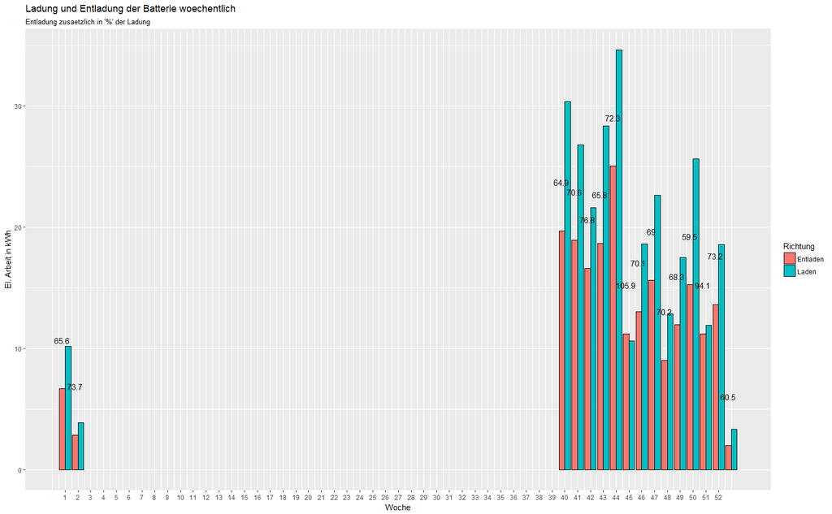

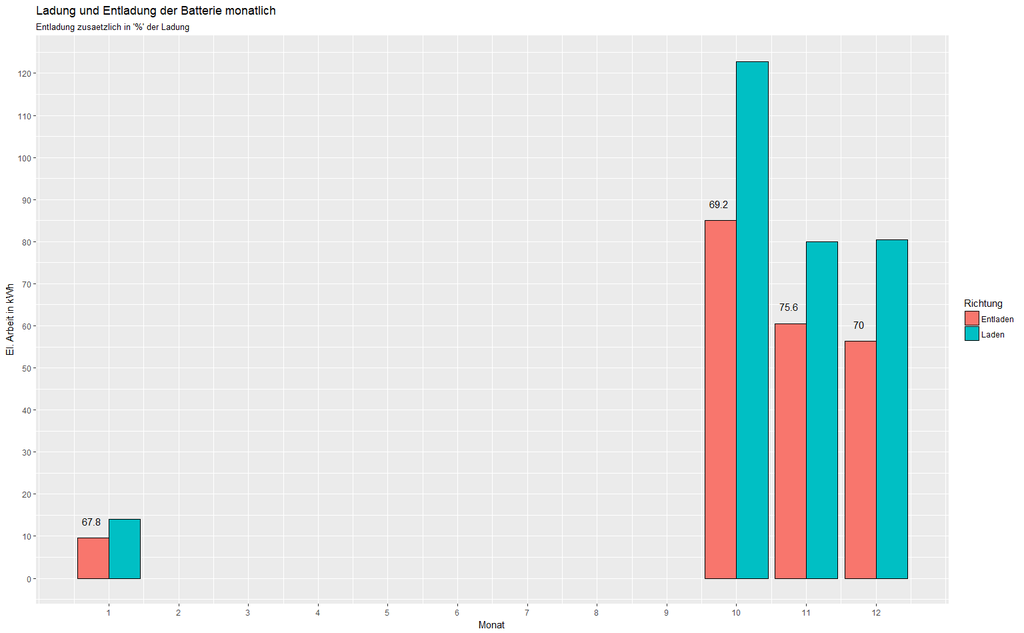

### Verbrauch und Erzeugung - Datenübersicht

Die folgenden Diagramme haben die selbe Struktur, wie entsprechende Seiten der Website http://sunnyportal.com/.

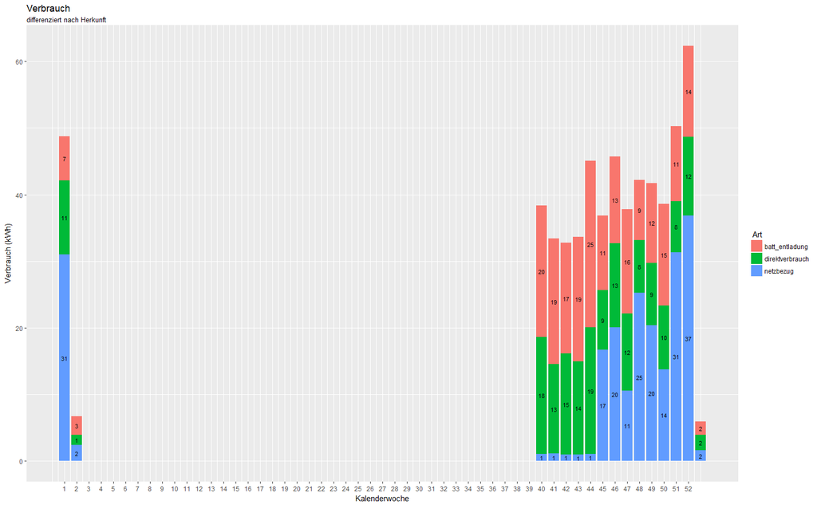

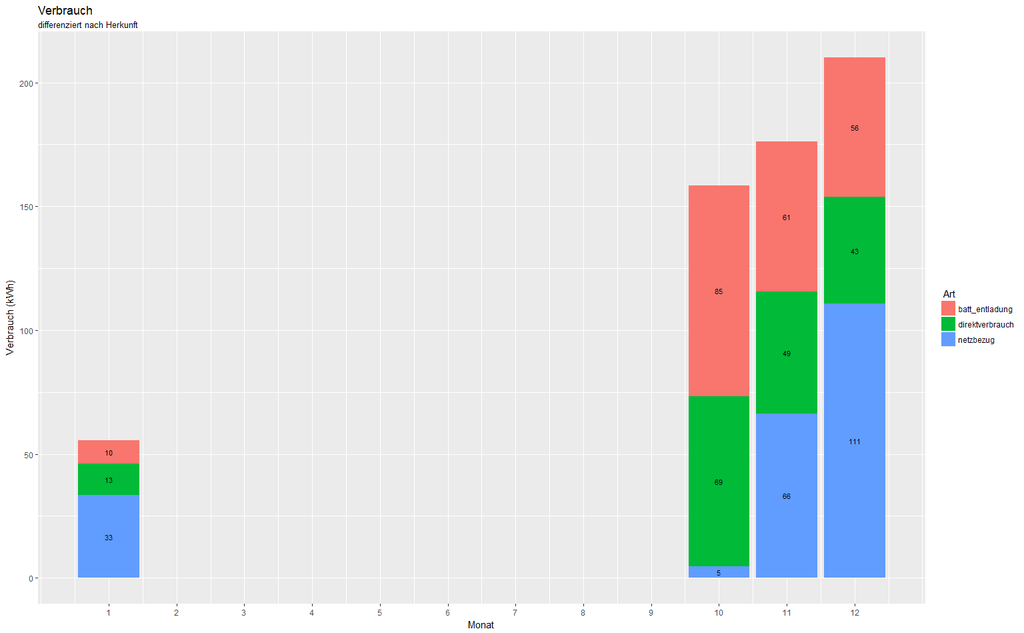

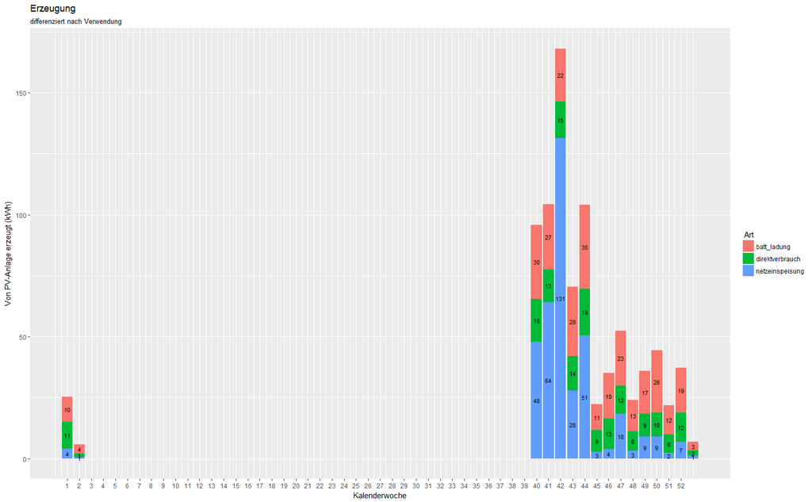

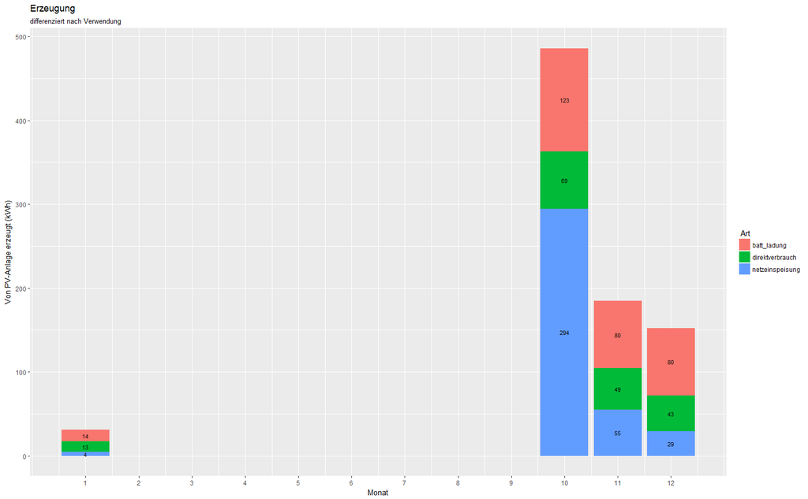

### Batteriezustand

Das folgende Diagramm zählt die Häufigkeit, mit der die Ladezustände der Batterie in den Monaten aufgetreten sind. Ausgezählt wird in Intervallen der Breite 0,400 kWh. (Amn: Ränder prüfen!)

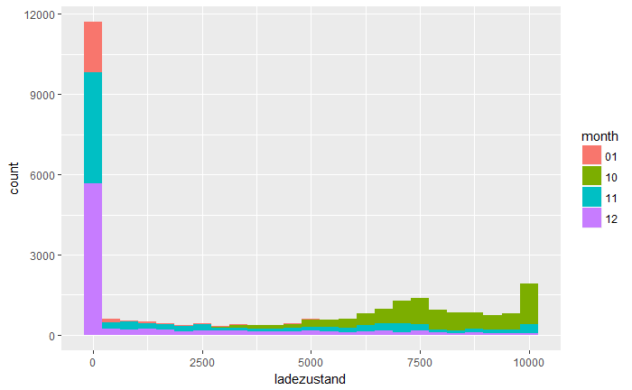

## Ladung und Entladung summieren und mit Ladezustand vergleichen

### Abschätzung von Wirkungsgraden für die Ladung bzw. die Entladung der Batterie

Durch die Annahme von zwei (konstanten) Wirkungsgraden für den Ladevorgang und den Entladevorgang kann aus den gemessenen Werten für die Batterieladung und -entladung fiktiv ein Ladezustand der Batterie berechnet und mit den Messwerten für den Ladezustand verglichen werden. Durch Auswahl der besten Approximation im Sinn einer geeigneten Norm ergibt sich eine Schätzung für die beiden Wirkungsgrade.

Mit Hilfe nichtlinearer Anpassung mit der Methode der kleinsten Quadrate erhält man Wirkungsgrade:

```
Fuer Ladung und Entladung ergeben sich die Wirkungsgrade 0.9849033  und 0.7080522
```

### Visualisierung der Aproxximationsqualität

Zum Vergleich: Verlauf des gemessenen und des modellierten Ladezustands

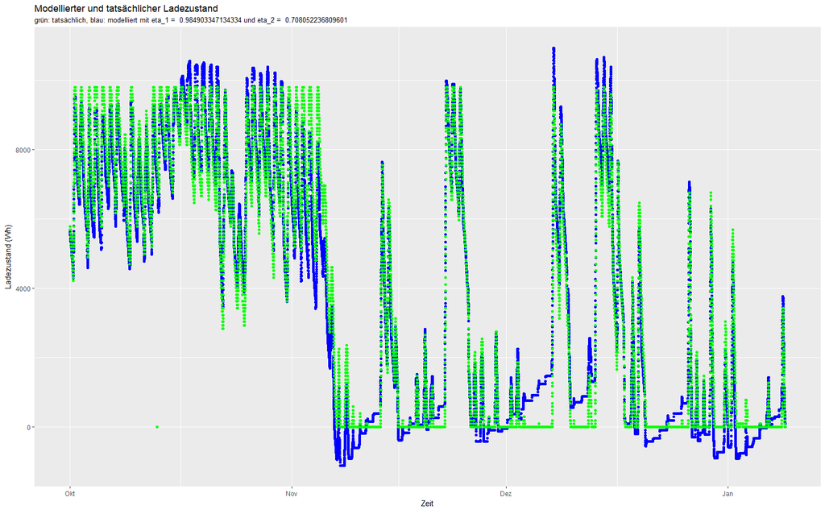

Aus dem Diagramm lässt sich erkennen, dass die Modellvorstellung eines konstanten Wirkungsgrades offensichtlich nur sehr grob gültig ist. Zu vermuten sind geänderte Wirkungsgrade im Bereich der beiden extremen LAdezustände nahe 100 bzw. 0 %.

## Strecken monotoner Entladung

Die beiden oben gefundenen Wirkungsgrade für das Laden der Batterie und für den Entladevorgang sollten sich auch wiederfinden lassen, wenn man Perioden beobachtet, in den die Batterie monoton geladen oder entladen wird. Dies ist das Ziel der folgenden Auswertung.

### Monotonie im Ladeverhalten

Es werden die zeitlichen Abschnitte erfasst, in denen die Ladebilanz (batt_ladung-batt_entladung) konstantes Vorzeichen (+/-1 oder 0) hat.Das Resultat des Ladevorgangs wird mit der Änderung des Ladezustands verglichen. Als Ausgangspunkt dient also das Ladeverhalten, die Summation der Werte wird verglichen mit dem tatsächlich erreichten Ladezustand.

Problematisch ist dabei, dass die Erfassung des **Ladezustands** wesentlich gröber ist (Schritte von ca. 100 Wh) als die des **Ladevorgangs**.

```
Vorkontrolle:Es werden
 11998 5min-Intervalle negativer und
 5892 Intervalle positiver Bilanz registiert.
 10903 Intervalle sind neutral.
```

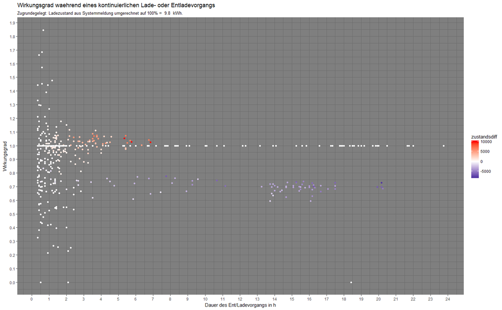

Bei kurzen Ladevorgängen streuen die Wirkungsgrade erwartungsgemäß sehr stark. Die Wirkungsgrade für Ladevorgänge (positiver Bilanz) streuen um Werte Nahe Eins (rote Punkte). Wegen der begrenzten Sonnenscheindauer kann die zugehörige Ladedauer bei den ausgewerteten Jahreszeiten 7 Stunden natürlich nicht überschreiten. Anders die Entladevorgänge, die bis zu fast einen Tag andauern können. Ihre Wirkungsgrade gruppieren sich um Werte bei 0,7 wie dies von der obigen Modellierung schon nahegelegt wurde.

### Bilanzierung der Differenzen orientiert am Ladezustand im Vergleich zu den Lade-/Entladevorgängen

Umgekehrt wie im vorigen Abschnitt erfolgt die Orientierung an den vorliegenden Ladezuständen bzw. ihren Sprüngen. Die Abschnitte zwischen zwei Sprüngen werden erfasst und die in dieser Zeit zugeführte/entnommene Energie bilanziert. Dies führt wieder zu einer Abschätzung der Wirkungsgrade.

Derzeit: Alle Wirkungsgrade für die Änderung eines Ladezustands werden gezeigt.

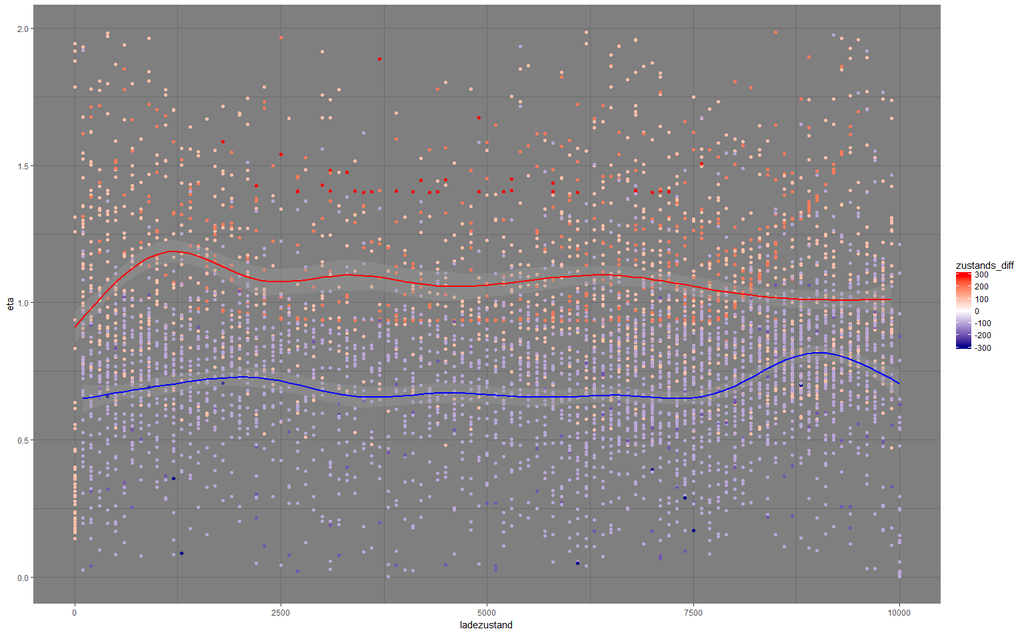

```r
# Minima und MAxima markieren frueher R_Min_Max_mark.R
# source("04_Auswertungen_Summ_Ent_Ladung_in_Tagesper.R")
```